# SSVEP reward - EEG results

### Inference about the best model

#### Attended vs. unattended

Check the difference between attended and not attended in baseline high rewarded

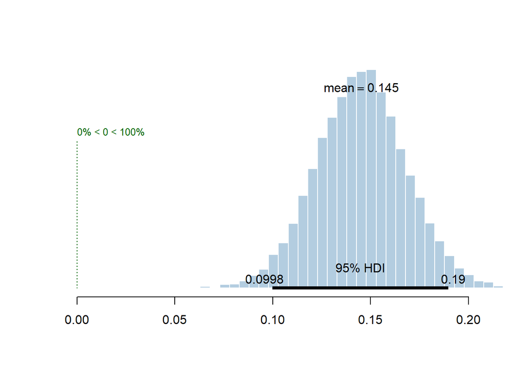

```r
Diff_Att_NotAtt_Bsln_High = Baseline_High_Attended - Baseline_High_NotAttended
plotPost(Diff_Att_NotAtt_Bsln_High, xlab = "", col = "#b3cde0", cex = 1, showCurve = FALSE, compVal = 0)
```

Check the difference between attended and not attended in baseline low rewarded

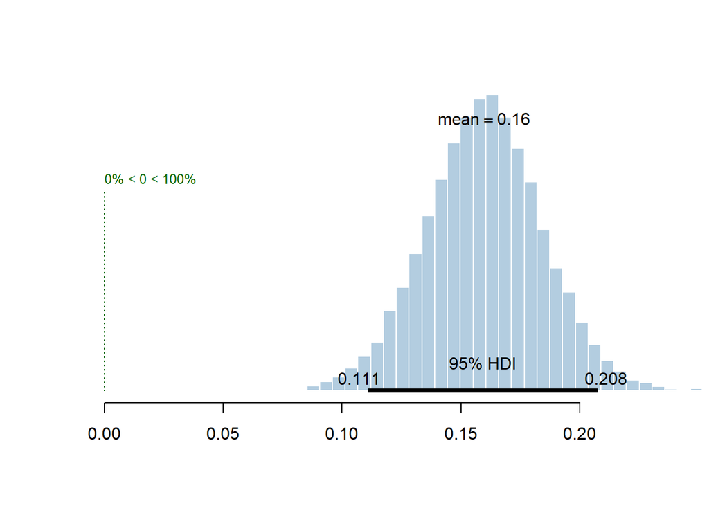

```r
Diff_Att_NotAtt_Bsln_Low = Baseline_Low_Attended - Baseline_Low_NotAttended
plotPost(Diff_Att_NotAtt_Bsln_Low, xlab = "", col = "#b3cde0", cex = 1, showCurve = FALSE, compVal = 0)
```

Check the difference between attended and not attended in acquisition high rewarded

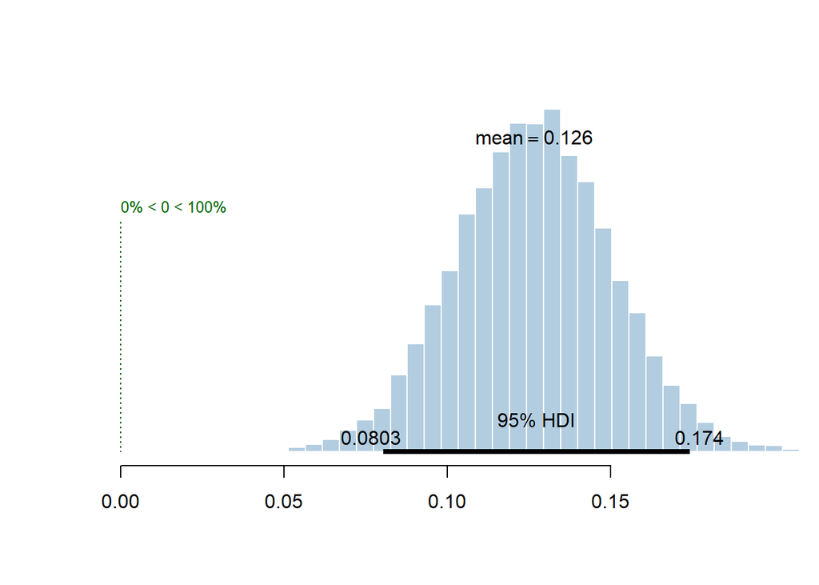

```r
Diff_Att_NotAtt_Acq_High = Acquisition_High_Attended - Acquisition_High_NotAttended
plotPost(Diff_Att_NotAtt_Acq_High, xlab = "", col = "#b3cde0", cex = 1, showCurve = FALSE, compVal = 0)
```

Check the difference between attended and not attended in acquisition low rewarded

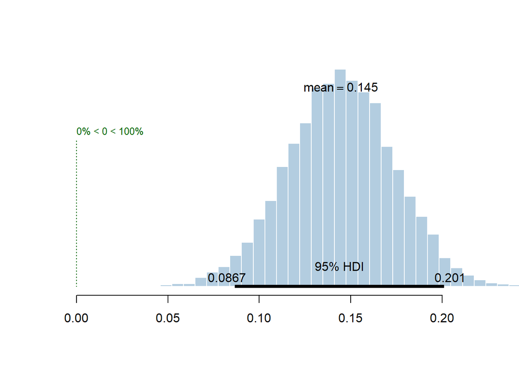

```r
Diff_Att_NotAtt_Acq_Low = Acquisition_Low_Attended - Acquisition_Low_NotAttended
plotPost(Diff_Att_NotAtt_Acq_Low, xlab = "", col = "#b3cde0", cex = 1, showCurve = FALSE, compVal = 0)
```

Check the difference between attended and not attended in extinction high rewarded

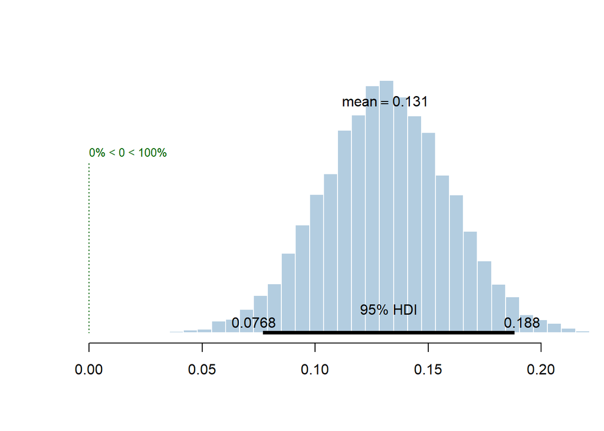

```r
Diff_Att_NotAtt_Ext_High = Extinction_High_Attended - Extinction_High_NotAttended
plotPost(Diff_Att_NotAtt_Ext_High, xlab = "", col = "#b3cde0", cex = 1, showCurve = FALSE, compVal = 0)
```

Check the difference between attended and not attended in extinction low rewarded

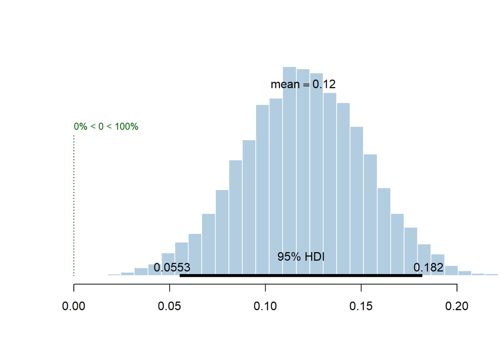

```r
Diff_Att_NotAtt_Ext_Low = Extinction_Low_Attended - Extinction_Low_NotAttended
plotPost(Diff_Att_NotAtt_Ext_Low, xlab = "", col = "#b3cde0", cex = 1, showCurve = FALSE, compVal = 0)
```

#### Comparison between phases

Check the difference between baseline and acquisition in high reward attended

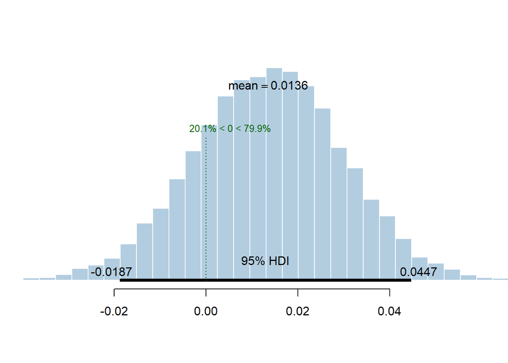

```r
Diff_Bsln_Acq_High_Att = Baseline_High_Attended - Acquisition_High_Attended
plotPost(Diff_Bsln_Acq_High_Att, xlab = "", col = "#b3cde0", cex = 1, showCurve = FALSE, compVal = 0)
```

Check the difference between baseline and acquisition in low reward attended

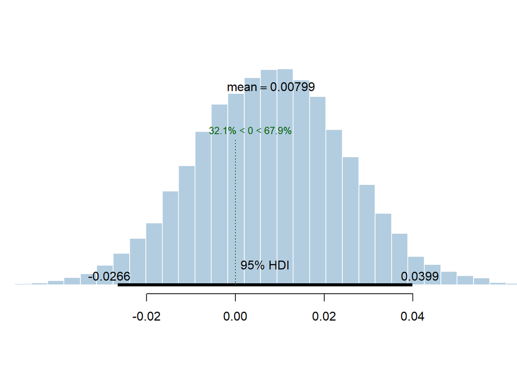

```r
Diff_Bsln_Acq_Low_Att = Baseline_Low_Attended - Acquisition_Low_Attended
plotPost(Diff_Bsln_Acq_Low_Att, xlab = "", col = "#b3cde0", cex = 1, showCurve = FALSE, compVal = 0)
```

Check the difference between baseline and acquisition in high reward not attended

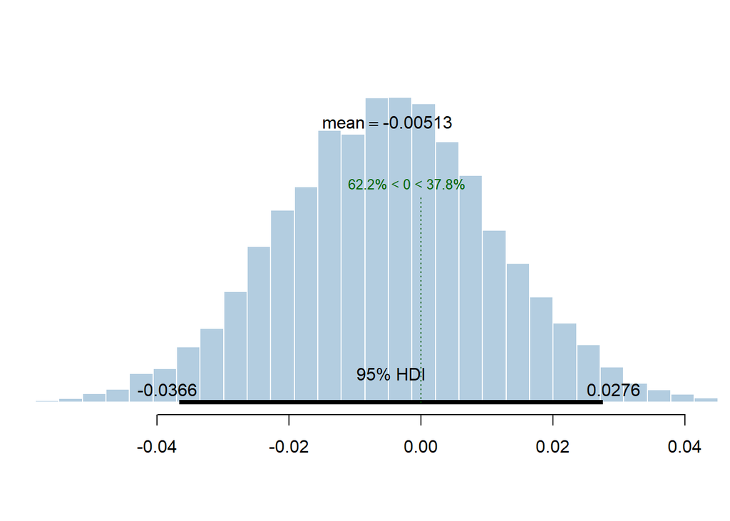

```r
Diff_Bsln_Acq_High_NotAtt = Baseline_High_NotAttended - Acquisition_High_NotAttended
plotPost(Diff_Bsln_Acq_High_NotAtt, xlab = "", col = "#b3cde0", cex = 1, showCurve = FALSE, compVal = 0)
```

Check the difference between baseline and acquisition in low reward not attended

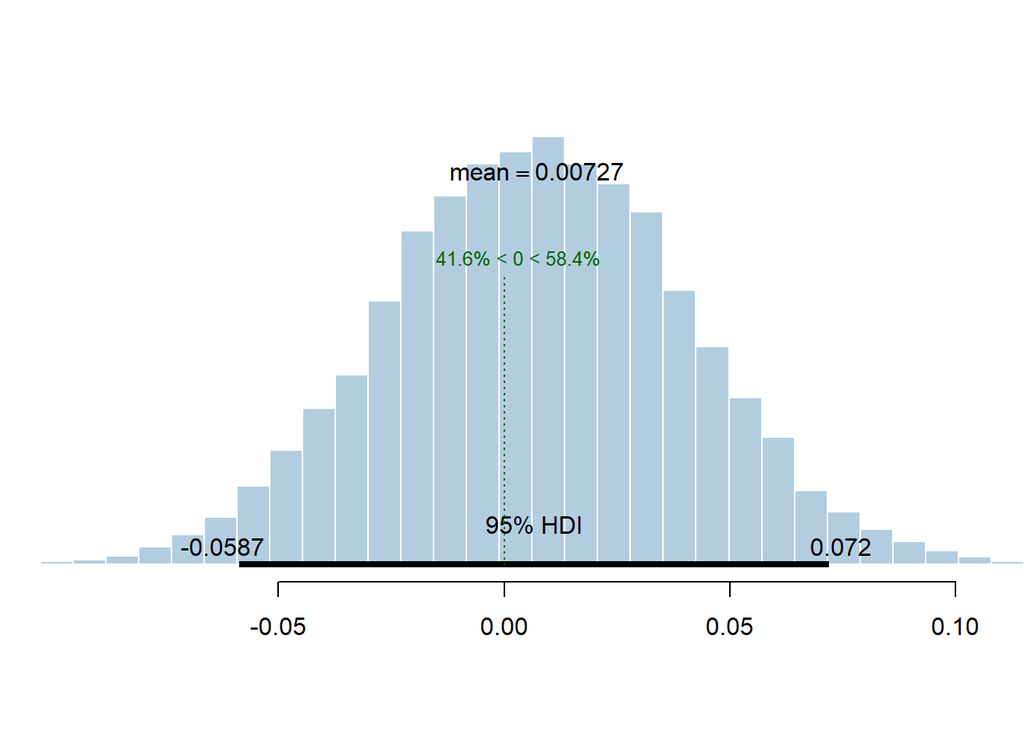

```r
Diff_Bsln_Acq_Low_NotAtt = Acquisition_Low_NotAttended - Baseline_Low_NotAttended
plotPost(Diff_Bsln_Acq_Low_NotAtt, xlab = "", col = "#b3cde0", cex = 1, showCurve = FALSE, compVal = 0)
```

Check the difference between acquisition and extinction in high reward attended

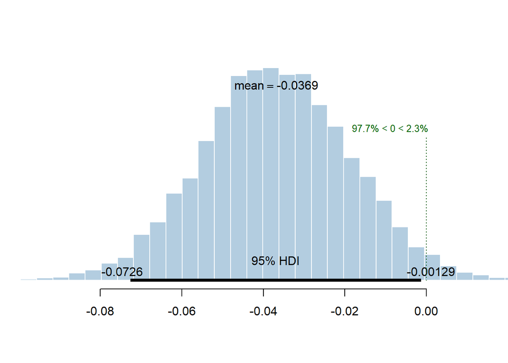

```r
Diff_Acq_Ext_High_Att = Acquisition_High_Attended - Extinction_High_Attended
plotPost(Diff_Acq_Ext_High_Att, xlab = "", col = "#b3cde0", cex = 1, showCurve = FALSE, compVal = 0)
```

Check the difference between acquisition and extinction in low reward attended

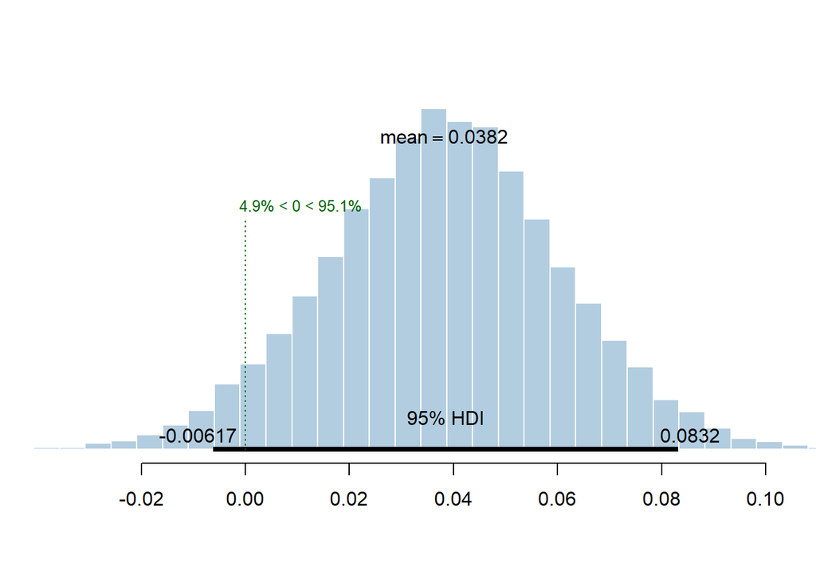

```r
Diff_Acq_Ext_Low_Att = Extinction_Low_Attended - Acquisition_Low_Attended
plotPost(Diff_Acq_Ext_Low_Att, xlab = "", col = "#b3cde0", cex = 1, showCurve = FALSE, compVal = 0)
```

Check the difference between acquisition and extinction in high reward not attended

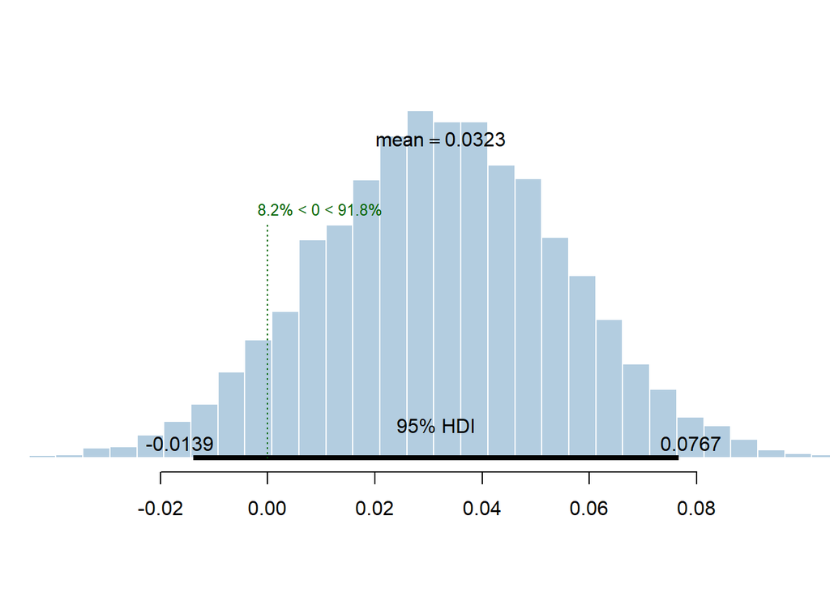

```r
Diff_Acq_Ext_High_NotAtt = Extinction_High_NotAttended - Acquisition_High_NotAttended
plotPost(Diff_Acq_Ext_High_NotAtt, xlab = "", col = "#b3cde0", cex = 1, showCurve = FALSE, compVal = 0)
```

Check the difference between acquisition and extinction in low reward not attended

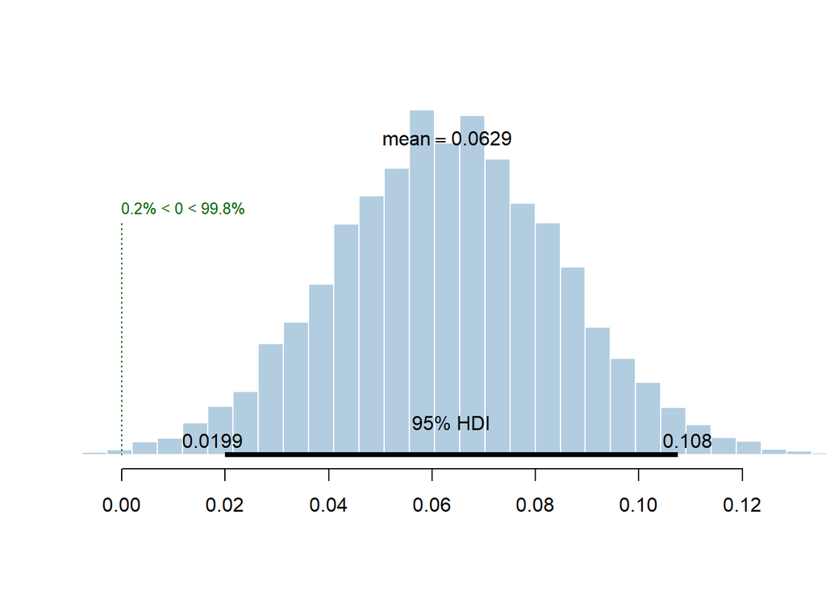

```r
Diff_Acq_Ext_Low_NotAtt = Extinction_Low_NotAttended - Acquisition_Low_NotAttended
plotPost(Diff_Acq_Ext_Low_NotAtt, xlab = "", col = "#b3cde0", cex = 1, showCurve = FALSE, compVal = 0)
```

#### Baseline difference

Check the difference between high and low reward in baseline attended

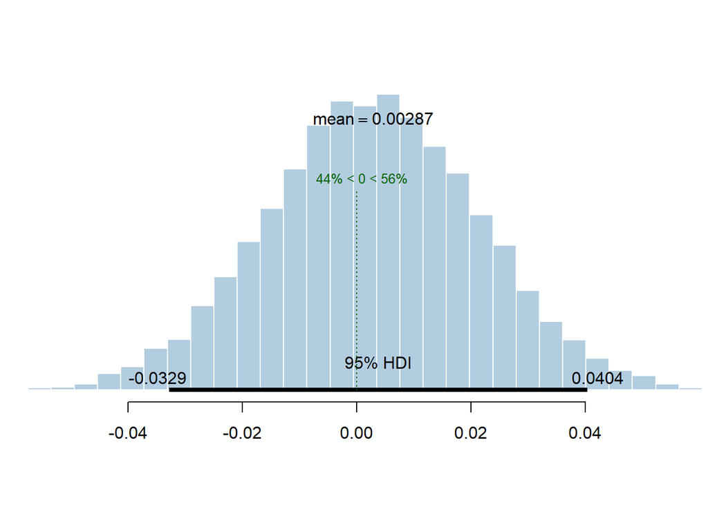

```r
Diff_Bsln_High_Low_Att = Baseline_High_Attended - Baseline_Low_Attended
plotPost(Diff_Bsln_High_Low_Att, xlab = "", col = "#b3cde0", cex = 1, showCurve = FALSE, compVal = 0)
```

Check the difference between high and low reward in baseline not attended

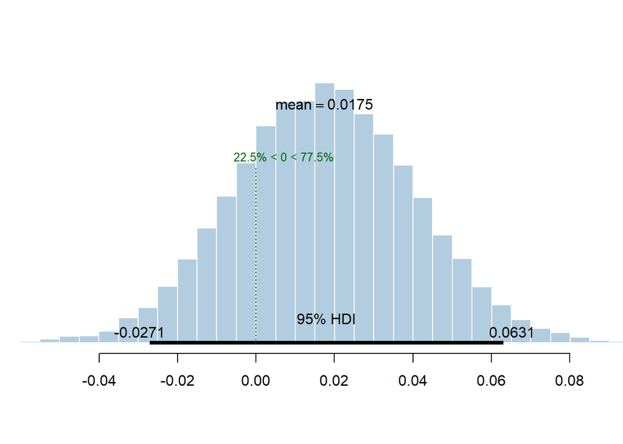

```r
Diff_Bsln_High_Low_NotAtt = Baseline_High_NotAttended - Baseline_Low_NotAttended
plotPost(Diff_Bsln_High_Low_NotAtt, xlab = "", col = "#b3cde0", cex = 1, showCurve = FALSE, compVal = 0)
```

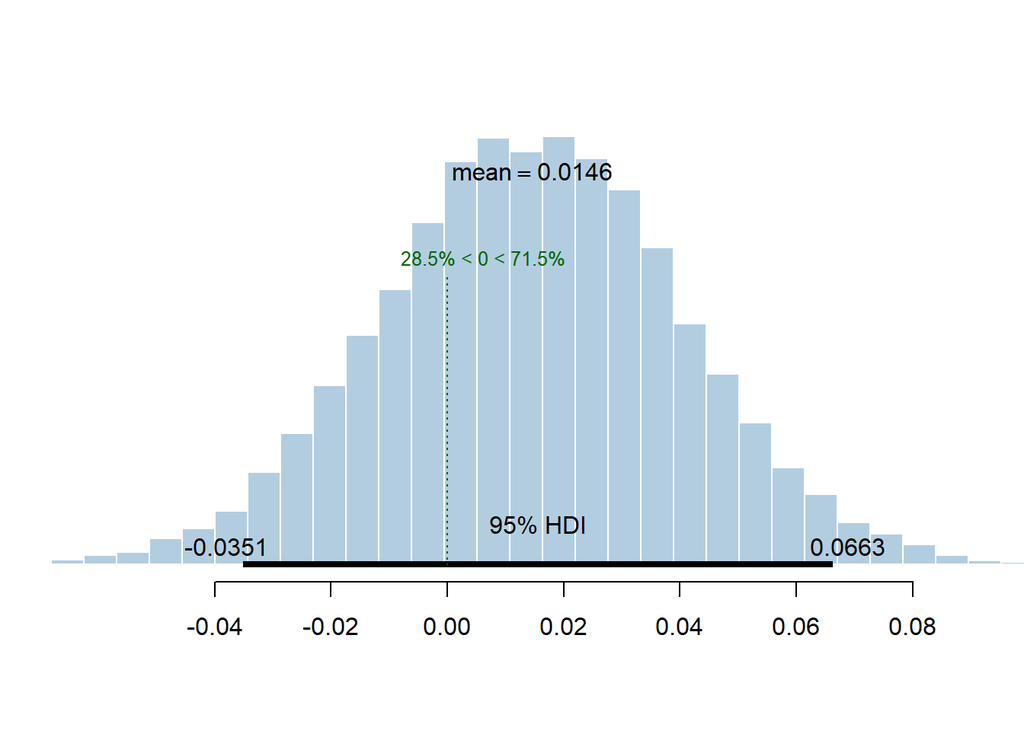

```r
Diff_Bsln_Acq_High_vs_Low_in_attended_vs_unattended = Diff_Bsln_High_Low_NotAtt - Diff_Bsln_High_Low_Att
plotPost(Diff_Bsln_Acq_High_vs_Low_in_attended_vs_unattended, xlab = "", col = "#b3cde0", showCurve = FALSE, cex = 1, compVal = 0)
```

```r
paste("Mean = ",round(mean(Diff_Bsln_Acq_High_vs_Low_in_attended_vs_unattended), digits = 2), " [", round(hdi(Diff_Bsln_Acq_High_vs_Low_in_attended_vs_unattended)[[1]], digits = 2), " ", round(hdi(Diff_Bsln_Acq_High_vs_Low_in_attended_vs_unattended)[[2]], digits = 2), "]")
```

```
## [1] "Mean =  0.01  [ -0.04   0.07 ]"
```

## Statistics - movement

```r
# Set the working directory in order to load the models
# Set working directory
setwd(here("brms_models"))

# # Set the intercept model
# data$ExpPhase=relevel(data$ExpPhase,ref="Bsln")
# data$Condition=relevel(data$Condition,ref="High_Rew")
# data$Attention=relevel(data$Attention,ref="Att")
#
#
# # Prior for the intercept only model
# prior = c(
#   prior(normal(1, 2), class = Intercept), #based on Anderson & Mueller, 2010 and on logic - max attention effect (removal of the unattended stimulus) == 2
#   prior(student_t(3, 0,3), class = sd),
#   prior(student_t(3, 0,3), class = sigma)
# )
#
# # Null model
# null = brm(Amplitude ~ 1 + (1|Subject),
#            data=data,
#            family=gaussian(),
#            prior = prior,
#            iter = 6000,
#            save_all_pars = TRUE,
#            control = list(adapt_delta = 0.99,max_treedepth = 15),
#            cores = 4,
#            sample_prior = TRUE,
#            inits = 0)
# saveRDS(null,file="null.EEG.allsub.rds")
#
# # Priors for the models with slopes
# prior = c(
#   prior(normal(1, 3), class = Intercept), #based on Anderson & Mueller, 2010 and on logic - max attention effect (removal of the unattended stimulus) == 2
#   prior(normal(0, 3), class = b), #based on Anderson & Mueller, 2010 and on logic - max attention effect (removal of the unattended stimulus) == 2
#   prior(student_t(3, 0,3), class = sd),
#   prior(student_t(3, 0,3), class = sigma)
#   )
#
# # Exp phase model
# expphase = brm(Amplitude ~ ExpPhase + (ExpPhase|Subject),
#                data=data,
#                family=gaussian(),
#                prior = prior,
#                iter = 6000,
#                save_all_pars = TRUE,
#                control = list(adapt_delta = 0.99,max_treedepth = 15),
#                cores = 4,
#                sample_prior = TRUE,
#                inits = 0)
# saveRDS(expphase,file="expphase.EEG.allsubs.rds")
#
# # Attention model
# attention = brm(Amplitude ~ Attention + (Attention|Subject),
#                 data=data,
#                 family=gaussian(),
#                 prior = prior,
#                 iter = 6000,
#                 save_all_pars = TRUE,
#                 control = list(adapt_delta = 0.99,max_treedepth = 15),
#                 cores = 4,
#                 sample_prior = TRUE,
#                 inits = 0)
# saveRDS(attention,file="attention.EEG.allsubs.rds")
#
# # Two main effects - phase and attention
# phaseANDattention = brm(Amplitude ~ ExpPhase + Attention + ( ExpPhase + Attention|Subject),
#                         data=data,
#                         family=gaussian(),
#                         prior = prior,
#                         iter = 6000,
#                         save_all_pars = TRUE,
#                         control = list(adapt_delta = 0.99,max_treedepth = 15),
#                         cores = 4,
#                         sample_prior = TRUE,
#                         inits = 0)
# saveRDS(phaseANDattention,file="phaseANDattention.EEG.allsubs.rds")
#
# # Interaction between phase and attention
# phaseANDattention_interaction = brm(Amplitude ~ ExpPhase * Attention + ( ExpPhase * Attention|Subject),
#                         data=data,
#                         family=gaussian(),
#                         prior = prior,
#                         iter = 6000,
#                         save_all_pars = TRUE,
#                         control = list(adapt_delta = 0.99,max_treedepth = 15),
#                         cores = 4,
#                         sample_prior = TRUE,
#                         inits = 0)
# saveRDS(phaseANDattention_interaction,file="phaseANDattention_interaction.EEG.allsubs.rds")
#
# # Interaction between expphase and reward magnitude plus attention
# rewardTimesPhasePlusAtt = brm(Amplitude ~ Condition * ExpPhase + Attention + (Condition * ExpPhase + Attention|Subject),
#                          data=data,
#                          family=gaussian(),
#                          prior = prior,
#                          iter = 6000,
#                          save_all_pars = TRUE,
#                          control = list(adapt_delta = 0.99,max_treedepth = 15),
#                          cores = 4,
#                          sample_prior = TRUE,
#                          inits = 0)
# saveRDS(rewardTimesPhasePlusAtt,file="rewardTimesPhasePlusAtt.EEG.allsubs.rds")
#
# # Full model
#
#
# full = brm(Amplitude ~ Condition * ExpPhase * Attention + (Condition * ExpPhase * Attention|Subject),
#                              data=data,
#                              family=gaussian(),
#                              prior = prior,
#                              iter = 6000,
#                              save_all_pars = TRUE,
#                              control = list(adapt_delta = 0.99,max_treedepth = 15),
#                              cores = 4,
#                              sample_prior = TRUE,
#                              inits = 0)
# saveRDS(full,file="full.EEG.allsubs.rds")
#
# # read in the models and comparisons
# null = readRDS("null.EEG.allsub.rds")
# attention = readRDS("attention.EEG.allsubs.rds")
# expphase = readRDS("expphase.EEG.allsubs.rds")
# phaseANDattention = readRDS("phaseANDattention.EEG.allsubs.rds")
# rewardTimesPhasePlusAtt = readRDS("rewardTimesPhasePlusAtt.EEG.allsubs.rds")
# full = readRDS("full.EEG.allsubs.rds")
# # waic = readRDS("compare.EEG.waic.allsubs.rds")
#
# # color_scheme_set("viridis")
# # pp_check(full, type = "stat_grouped", nsamples = 100, group = "ExpPhase")
#
# # WAIC
# compare.EEG.waic = WAIC(null, expphase, attention, phaseANDattention, rewardTimesPhasePlusAtt, full, compare = TRUE)
# saveRDS(compare.EEG.waic,file="compare.EEG.waic.allsubs.rds")
#
# # Weighted waic
# compare.EEG.waic.weights = model_weights(null, expphase, attention, phaseANDattention, rewardTimesPhasePlusAtt, full, weights = "waic")
# saveRDS(compare.EEG.waic.weights,file="compare.EEG.waic.weights")
#
# # Bayesian R2
# #Null
# bR2.null.EEG = bayes_R2(null)
# saveRDS(bR2.null.EEG,file="bR2.null.EEG")
# #ExpPhase
# bR2.expphase.EEG = bayes_R2(expphase)
# saveRDS(bR2.expphase.EEG,file="bR2.expphase.EEG")
# #Phase and attention
# bR2.phaseANDattention.EEG = bayes_R2(phaseANDattention)
# saveRDS(bR2.phaseANDattention.EEG,file="bR2.phaseANDattention.EEG")
# #Reward times phase plus attention
# bR2.rewardTimesPhasePlusAtt.EEG = bayes_R2(rewardTimesPhasePlusAtt)
# saveRDS(bR2.rewardTimesPhasePlusAtt.EEG,file="bR2.rewardTimesPhasePlusAtt.EEG")
# #Full
# bR2.full.EEG = bayes_R2(model.full.EEG)
# saveRDS(bR2.full.EEG,file="bR2.full.EEG")


# read in the models and comparisons
# null = readRDS("null.EEG.allsub.rds")
# attention = readRDS("attention.EEG.allsubs.rds")
# expphase = readRDS("expphase.EEG.allsubs.rds")
# phaseANDattention = readRDS("phaseANDattention.EEG.allsubs.rds")
# rewardTimesPhasePlusAtt = readRDS("rewardTimesPhasePlusAtt.EEG.allsubs.rds")
model.full.threefactors = readRDS("full.EEG.allsubs.movement.rds")
compare.threefactors.EEG.waic = readRDS("compare.EEG.waic.allsubs.movement.rds")
# compare.EEG.waic.weights = readRDS("compare.EEG.waic.weights")
bR2.null.EEG = readRDS("bR2.null.EEG.movement")
bR2.expphase.EEG = readRDS("bR2.expphase.EEG.movement")
bR2.attention.EEG = readRDS("bR2.attention.EEG.movement")
bR2.phaseANDattention.EEG = readRDS("bR2.phaseANDattention.EEG.movement")
bR2.phaseANDattention_interaction.EEG = readRDS("bR2.phaseANDattention_interaction.EEG.movement")
bR2.rewardTimesPhasePlusAtt.EEG = readRDS("bR2.rewardTimesPhasePlusAtt.EEG.movement")
bR2.full.EEG = readRDS("bR2.full.EEG.movement")
```

### Model comparison with WAIC

```r
print(compare.threefactors.EEG.waic)
```

```
##                                                             WAIC     SE
## null                                                    24659.96 316.21
## expphase                                                24523.75 315.31
## attention                                               23075.78 327.42
## phaseANDattention                                       22925.12 326.68
## phaseANDattention_interaction                           22912.07 326.76
## rewardTimesPhasePlusAtt                                 22542.56 329.52
## full                                                    22350.41 331.21
## null - expphase                                           136.21  25.02
## null - attention                                         1584.18  72.21
## null - phaseANDattention                                 1734.84  76.61
## null - phaseANDattention_interaction                     1747.89  77.21
## null - rewardTimesPhasePlusAtt                           2117.40  85.81
## null - full                                              2309.55  90.73
## expphase - attention                                     1447.97  76.61
## expphase - phaseANDattention                             1598.63  72.52
## expphase - phaseANDattention_interaction                 1611.67  73.06
## expphase - rewardTimesPhasePlusAtt                       1981.19  82.34
## expphase - full                                          2173.34  87.29
## attention - phaseANDattention                             150.66  26.24
## attention - phaseANDattention_interaction                 163.70  27.89
## attention - rewardTimesPhasePlusAtt                       533.22  45.95
## attention - full                                          725.37  54.24
## phaseANDattention - phaseANDattention_interaction          13.04   8.74
## phaseANDattention - rewardTimesPhasePlusAtt               382.56  37.93
## phaseANDattention - full                                  574.71  47.33
## phaseANDattention_interaction - rewardTimesPhasePlusAtt   369.52  38.92
## phaseANDattention_interaction - full                      561.67  46.29
## rewardTimesPhasePlusAtt - full                            192.15  27.15
```

### Model comparison with WAIC weights

```r
#print(compare.EEG.waic.weights)
```

### Bayesian R squared

Null model

```r
print(bR2.null.EEG)
```

```
##       Estimate   Est.Error        Q2.5      Q97.5
## R2 0.008792047 0.001136642 0.006670665 0.01112064
```

Experiment phase

```r
print(bR2.expphase.EEG)
```

```
##      Estimate   Est.Error       Q2.5      Q97.5
## R2 0.01510378 0.001500609 0.01225833 0.01810926
```

Attention model

```r
print(bR2.attention.EEG)
```

```
##      Estimate Est.Error       Q2.5     Q97.5
## R2 0.06332869 0.0027005 0.05820361 0.0686511
```

Phase and attention model

```r
print(bR2.phaseANDattention.EEG)
```

```
##      Estimate   Est.Error       Q2.5      Q97.5
## R2 0.06980036 0.002879709 0.06422838 0.07548723
```

Phase and attention interaction model

```r
print(bR2.phaseANDattention_interaction.EEG)
```

```
##      Estimate   Est.Error       Q2.5      Q97.5
## R2 0.07145151 0.002894393 0.06591713 0.07720121
```

Reward times phase plus attention model

```r
print(bR2.rewardTimesPhasePlusAtt.EEG)
```

```
##      Estimate   Est.Error       Q2.5     Q97.5
## R2 0.08421852 0.003047519 0.07831835 0.0902795
```

Full model

```r
print(bR2.full.EEG)
```

```
##      Estimate   Est.Error       Q2.5    Q97.5
## R2 0.09456452 0.003269437 0.08826584 0.101022
```

### Checking the best model

Plotting the chains

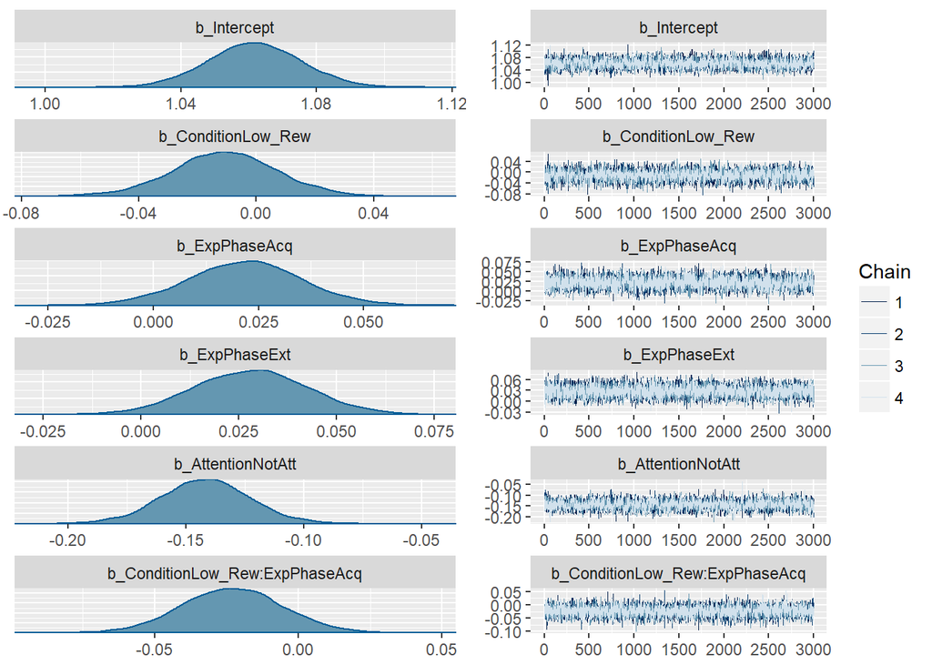

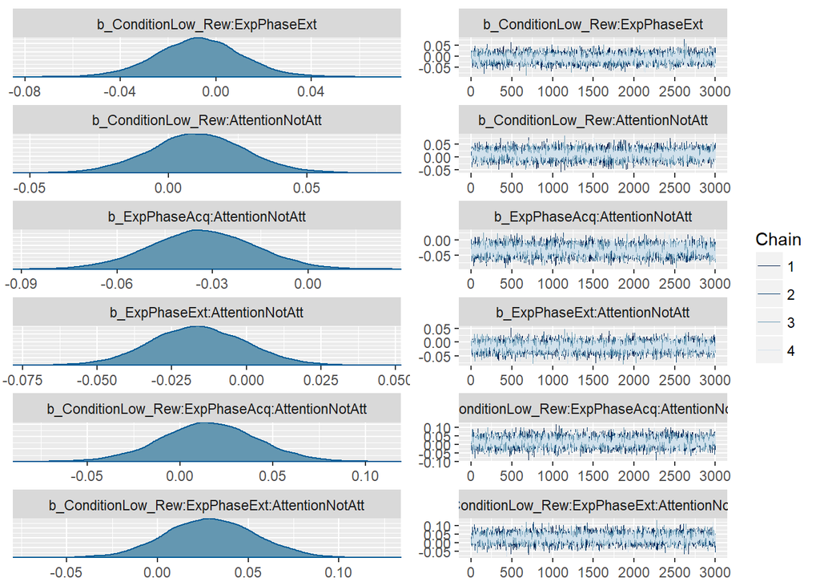

```r
# Plot chains
plot(model.full.threefactors, pars = "^b_", ask = FALSE, N=6)
```

Summary of the best model

```r
# Summary of the best model
print(tidy(model.full.threefactors, par_type = "non-varying"), digits = 1)
```

```
##                                            term estimate std.error  lower
## 1                                     Intercept    1.062      0.01  1e+00
## 2                              ConditionLow_Rew   -0.011      0.02 -4e-02
## 3                                   ExpPhaseAcq    0.022      0.01 -9e-04
## 4                                   ExpPhaseExt    0.028      0.01  4e-03
## 5                               AttentionNotAtt   -0.142      0.02 -2e-01
## 6                  ConditionLow_Rew:ExpPhaseAcq   -0.023      0.02 -5e-02
## 7                  ConditionLow_Rew:ExpPhaseExt   -0.007      0.02 -4e-02
## 8              ConditionLow_Rew:AttentionNotAtt    0.010      0.02 -2e-02
## 9                   ExpPhaseAcq:AttentionNotAtt   -0.033      0.02 -6e-02
## 10                  ExpPhaseExt:AttentionNotAtt   -0.016      0.02 -4e-02
## 11 ConditionLow_Rew:ExpPhaseAcq:AttentionNotAtt    0.015      0.03 -3e-02
## 12 ConditionLow_Rew:ExpPhaseExt:AttentionNotAtt    0.029      0.03 -1e-02
##     upper
## 1   1.084
## 2   0.019
## 3   0.044
## 4   0.052
## 5  -0.111
## 6   0.006
## 7   0.021
## 8   0.039
## 9  -0.006
## 10  0.010
## 11  0.058
## 12  0.071
```

### Plotting the best model

```r
post = posterior_samples(model.full.threefactors, "^b")

# Calculate posteriors for each condition

################################################ Baseline ####

##################### Attended

######### High reward
Baseline_High_Attended = post[["b_Intercept"]]
######### Low reward
Baseline_Low_Attended = post[["b_Intercept"]] +
  post[["b_ConditionLow_Rew"]]

##################### Not Attended

######### High reward
Baseline_High_NotAttended = post[["b_Intercept"]] +
  post[["b_AttentionNotAtt"]]
######### Low reward
Baseline_Low_NotAttended = post[["b_Intercept"]] +
  post[["b_AttentionNotAtt"]] +
  post[["b_ConditionLow_Rew"]] +
  post[["b_ConditionLow_Rew:AttentionNotAtt"]]

################################################ Acquistion

##################### Attended

######### High reward
Acquisition_High_Attended = post[["b_Intercept"]] +
  post[["b_ExpPhaseAcq"]]
######### Low reward
Acquisition_Low_Attended = post[["b_Intercept"]] +
  post[["b_ExpPhaseAcq"]] +
  post[["b_ConditionLow_Rew"]] +
  post[["b_ConditionLow_Rew:ExpPhaseAcq"]]

##################### Not Attended

######### High reward
Acquisition_High_NotAttended = post[["b_Intercept"]] +
  post[["b_ExpPhaseAcq"]] +
  post[["b_AttentionNotAtt"]] +
  post[["b_ExpPhaseAcq:AttentionNotAtt"]]

######### Low reward
Acquisition_Low_NotAttended = post[["b_Intercept"]] +
  post[["b_ExpPhaseAcq"]] +
  post[["b_AttentionNotAtt"]] +
  post[["b_ConditionLow_Rew"]] +
  post[["b_ExpPhaseAcq:AttentionNotAtt"]] +
  post[["b_ConditionLow_Rew:ExpPhaseAcq"]] +
  post[["b_ConditionLow_Rew:ExpPhaseAcq:AttentionNotAtt"]]

################################################ Extinction

##################### Attended

######### High reward
Extinction_High_Attended = post[["b_Intercept"]] +
  post[["b_ExpPhaseExt"]]
######### Low reward
Extinction_Low_Attended = post[["b_Intercept"]] +
  post[["b_ExpPhaseExt"]] +
  post[["b_ConditionLow_Rew"]] +
  post[["b_ConditionLow_Rew:ExpPhaseExt"]]

##################### Not Attended

######### High reward
Extinction_High_NotAttended = post[["b_Intercept"]] +
  post[["b_ExpPhaseExt"]] +
  post[["b_AttentionNotAtt"]] +
  post[["b_ExpPhaseExt:AttentionNotAtt"]]
######### Low reward
Extinction_Low_NotAttended = post[["b_Intercept"]] +
  post[["b_ExpPhaseExt"]] +
  post[["b_AttentionNotAtt"]] +
  post[["b_ConditionLow_Rew"]] +
  post[["b_ExpPhaseExt:AttentionNotAtt"]] +
  post[["b_ConditionLow_Rew:ExpPhaseExt"]] +
  post[["b_ConditionLow_Rew:ExpPhaseExt:AttentionNotAtt"]]
```

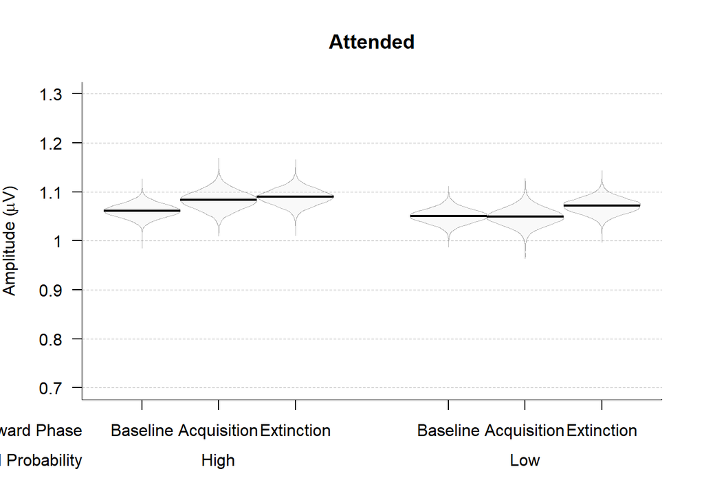

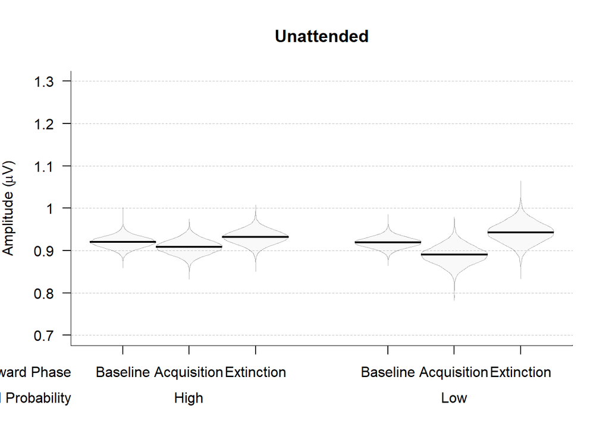

```r
# make a data frame

posterior_conditions = melt(data.frame(Baseline_High_Attended, Baseline_High_NotAttended, Baseline_Low_Attended, Baseline_Low_NotAttended, Acquisition_High_Attended, Acquisition_High_NotAttended, Acquisition_Low_Attended, Acquisition_Low_NotAttended, Extinction_High_Attended, Extinction_High_NotAttended, Extinction_Low_Attended, Extinction_Low_NotAttended))

posterior_conditions =  posterior_conditions %>% separate(variable, c("Reward Phase", "Reward Probability", "Attention"), "_", extra = "merge")

posterior_conditions$Attention = recode(posterior_conditions$Attention,
                           "Attended" = "Attended",
                           "NotAttended" = "Unattended")

names(posterior_conditions)[4] = "Amplitude"


#order
#dataPlot$`Reward phase` = factor(dataPlot$`Reward phase`, levels = c("Baseline","Acquisition","Extinction"))
#dataPlot = dataPlot[order(dataPlot$Attention,dataPlot$`Reward phase`,dataPlot$`Reward probability`),]


plottingConditions = c("Attended","Unattended" )
for (i in 1:length(plottingConditions)){

  if(plottingConditions[i]=="Attended"){dataAmplitudePlot=subset(posterior_conditions,Attention=="Attended")}

  if(plottingConditions[i]=="Unattended"){dataAmplitudePlot=subset(posterior_conditions,Attention=="Unattended")}

# Pirate plot

    pirateplot(formula = Amplitude ~ `Reward Phase` + `Reward Probability`, # dependent~independent variables
             data=dataAmplitudePlot, # data frame
             main=plottingConditions[i], # main title
             ylim=c(0.7,1.3), # y-axis: limits
             ylab=expression(paste("Amplitude (",mu,"V)")), # y-axis: label
             theme=0, # preset theme (0: use your own)
             avg.line.col="black", # average line: color
             avg.line.lwd=2, # average line: line width
             avg.line.o=1, # average line: opacity (0-1)
             bean.b.col="black", # bean border, color
             bean.lwd=0.6, # bean border, line width
             bean.lty=1, # bean border, line type (1: solid; 2:dashed; 3: dotted; ...)
             bean.b.o=0.3, # bean border, opacity (0-1)
             bean.f.col="gray", # bean filling, color
             bean.f.o=.1, # bean filling, opacity (0-1)
             cap.beans=FALSE, # max and min values of bean densities are capped at the limits found in the data
             gl.col="gray", # gridlines: color
             gl.lty=2, # gridlines: line type (1: solid; 2:dashed; 3: dotted; ...)
             cex.lab=1, # axis labels: size
             cex.axis=1, # axis numbers: size
             cex.names = 1,
             sortx = "sequential",
             bty="l", # plot box type
             back.col="white") # background, color
}
```

Table of means across conditions

```r
# Make a table with conditions
posterior_means = as.data.frame(c("Attended Baseline High Reward",
                                  "Attended Baseline Low Reward",
                                  "Attended Acquisition High Reward",
                                  "Attended Acquisition Low Reward",
                                  "Attended Extinction High Reward",
                                  "Attended Extinction Low Reward",
                                  "Unattended Baseline High Reward",
                                  "Unattended Baseline Low Reward",
                                  "Unattended Acquisition High Reward",
                                  "Unattended Acquisition Low Reward",
                                  "Unattended Extinction High Reward",
                                  "Unattended Extinction Low Reward"))
names(posterior_means)[1] = "Condition"

posterior_means$Mean = c(paste(round(mean(Baseline_High_Attended), digits = 2), " [", round(hdi(Baseline_High_Attended)[[1]], digits = 2), " ", round(hdi(Baseline_High_Attended)[[2]], digits = 2), "]"),
                        paste(round(mean(Baseline_Low_Attended), digits = 2), " [", round(hdi(Baseline_Low_Attended)[[1]], digits = 2), " ", round(hdi(Baseline_Low_Attended)[[2]], digits = 2), "]"),

                        paste(round(mean(Acquisition_High_Attended), digits = 2), " [", round(hdi(Acquisition_High_Attended)[[1]], digits = 2), " ", round(hdi(Acquisition_High_Attended)[[2]], digits = 2), "]"),
                        paste(round(mean(Acquisition_Low_Attended), digits = 2), " [", round(hdi(Acquisition_Low_Attended)[[1]], digits = 2), " ", round(hdi(Acquisition_Low_Attended)[[2]], digits = 2), "]"),
                        paste(round(mean(Extinction_High_Attended), digits = 2), " [", round(hdi(Extinction_High_Attended)[[1]], digits = 2), " ", round(hdi(Extinction_High_Attended)[[2]], digits = 2), "]"),
                        paste(round(mean(Extinction_Low_Attended), digits = 2), " [", round(hdi(Extinction_Low_Attended)[[1]], digits = 2), " ", round(hdi(Extinction_Low_Attended)[[2]], digits = 2), "]"),
                        paste(round(mean(Baseline_High_NotAttended), digits = 2), " [", round(hdi(Baseline_High_NotAttended)[[1]], digits = 2), " ", round(hdi(Baseline_High_NotAttended)[[2]], digits = 2), "]"),
                        paste(round(mean(Baseline_Low_NotAttended), digits = 2), " [", round(hdi(Baseline_Low_NotAttended)[[1]], digits = 2), " ", round(hdi(Baseline_Low_NotAttended)[[2]], digits = 2), "]"),
                        paste(round(mean(Acquisition_High_NotAttended), digits = 2), " [", round(hdi(Acquisition_High_NotAttended)[[1]], digits = 2), " ", round(hdi(Acquisition_High_NotAttended)[[2]], digits = 2), "]"),
                        paste(round(mean(Acquisition_Low_NotAttended), digits = 2), " [", round(hdi(Acquisition_Low_NotAttended)[[1]], digits = 2), " ", round(hdi(Acquisition_Low_NotAttended)[[2]], digits = 2), "]"),
                        paste(round(mean(Extinction_High_NotAttended), digits = 2), " [", round(hdi(Extinction_High_NotAttended)[[1]], digits = 2), " ", round(hdi(Extinction_High_NotAttended)[[2]], digits = 2), "]"),
                        paste(round(mean(Extinction_Low_NotAttended), digits = 2), " [", round(hdi(Extinction_Low_NotAttended)[[1]], digits = 2), " ", round(hdi(Extinction_Low_NotAttended)[[2]], digits = 2), "]"))

names(posterior_means)[2] = "Mean [HDI]"

posterior_means =  posterior_means %>% separate(Condition, c("Attention", "Reward Phase", "Reward Probability"), " ", extra = "merge")

kable(posterior_means, caption = "Means per condition")
```

Means per condition

| Attention | Reward Phase | Reward Probability | Mean [HDI] |
| --- | --- | --- | --- |
| Attended | Baseline | High Reward | 1.06 [ 1.04 1.09 ] |
| Attended | Baseline | Low Reward | 1.05 [ 1.02 1.08 ] |
| Attended | Acquisition | High Reward | 1.08 [ 1.05 1.12 ] |
| Attended | Acquisition | Low Reward | 1.05 [ 1.02 1.09 ] |
| Attended | Extinction | High Reward | 1.09 [ 1.06 1.12 ] |
| Attended | Extinction | Low Reward | 1.07 [ 1.04 1.1 ] |
| Unattended | Baseline | High Reward | 0.92 [ 0.89 0.95 ] |
| Unattended | Baseline | Low Reward | 0.92 [ 0.89 0.94 ] |
| Unattended | Acquisition | High Reward | 0.91 [ 0.88 0.94 ] |
| Unattended | Acquisition | Low Reward | 0.89 [ 0.85 0.93 ] |
| Unattended | Extinction | High Reward | 0.93 [ 0.9 0.96 ] |
| Unattended | Extinction | Low Reward | 0.94 [ 0.89 0.99 ] |

### Inference about the best model

#### Attended vs. unattended

Check the difference between attended and not attended in baseline high rewarded

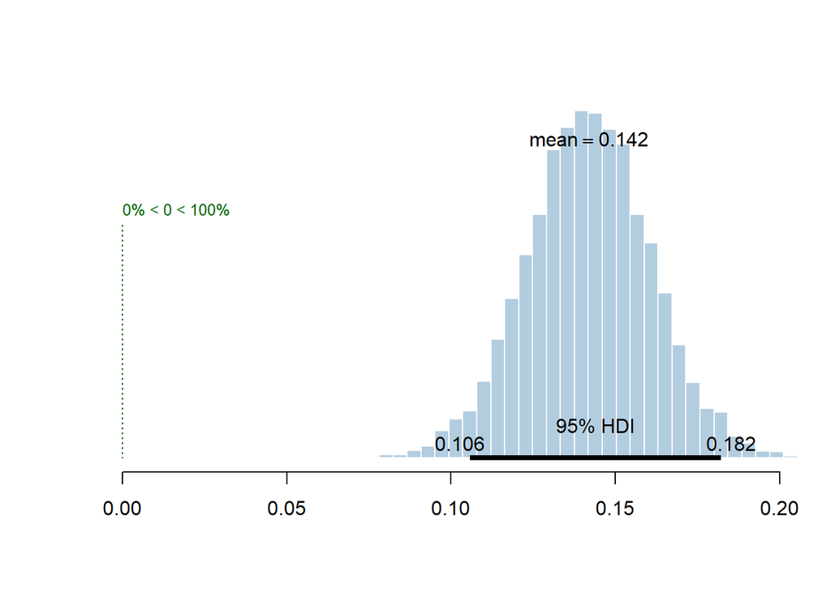

```r
Diff_Att_NotAtt_Bsln_High = Baseline_High_Attended - Baseline_High_NotAttended
plotPost(Diff_Att_NotAtt_Bsln_High, xlab = "", col = "#b3cde0", cex = 1, showCurve = FALSE, compVal = 0)
```

Check the difference between attended and not attended in baseline low rewarded

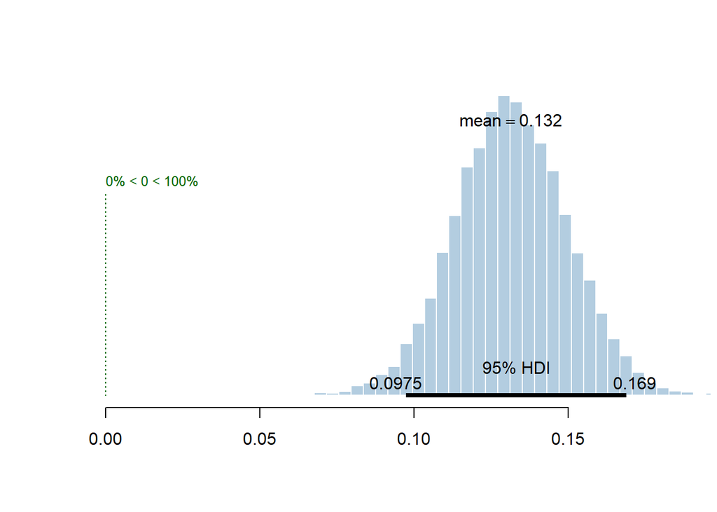

```r
Diff_Att_NotAtt_Bsln_Low = Baseline_Low_Attended - Baseline_Low_NotAttended
plotPost(Diff_Att_NotAtt_Bsln_Low, xlab = "", col = "#b3cde0", cex = 1, showCurve = FALSE, compVal = 0)
```

Check the difference between attended and not attended in acquisition high rewarded

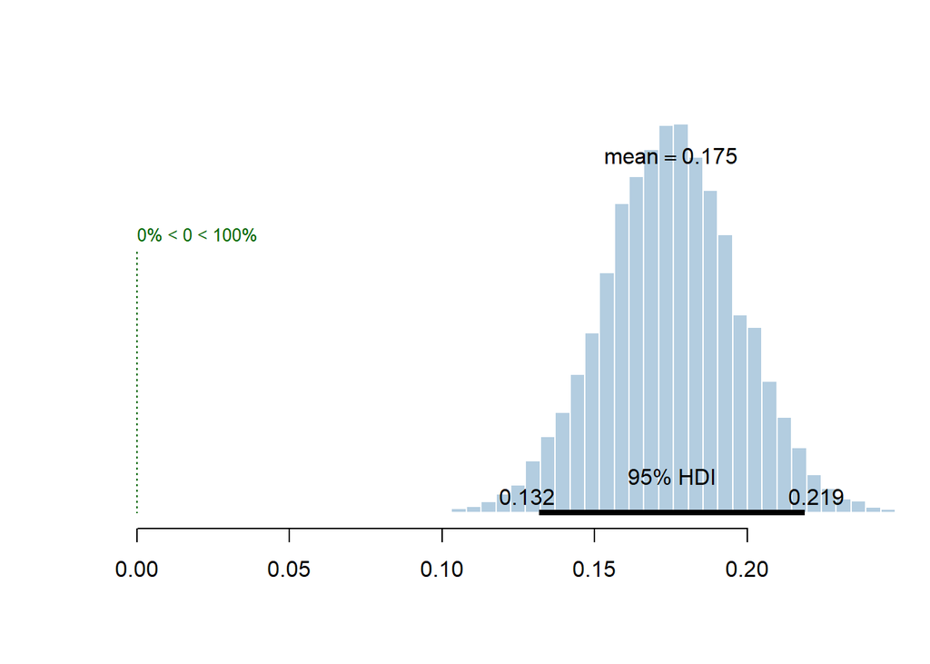

```r
Diff_Att_NotAtt_Acq_High = Acquisition_High_Attended - Acquisition_High_NotAttended
plotPost(Diff_Att_NotAtt_Acq_High, xlab = "", col = "#b3cde0", cex = 1, showCurve = FALSE, compVal = 0)
```

Check the difference between attended and not attended in acquisition low rewarded

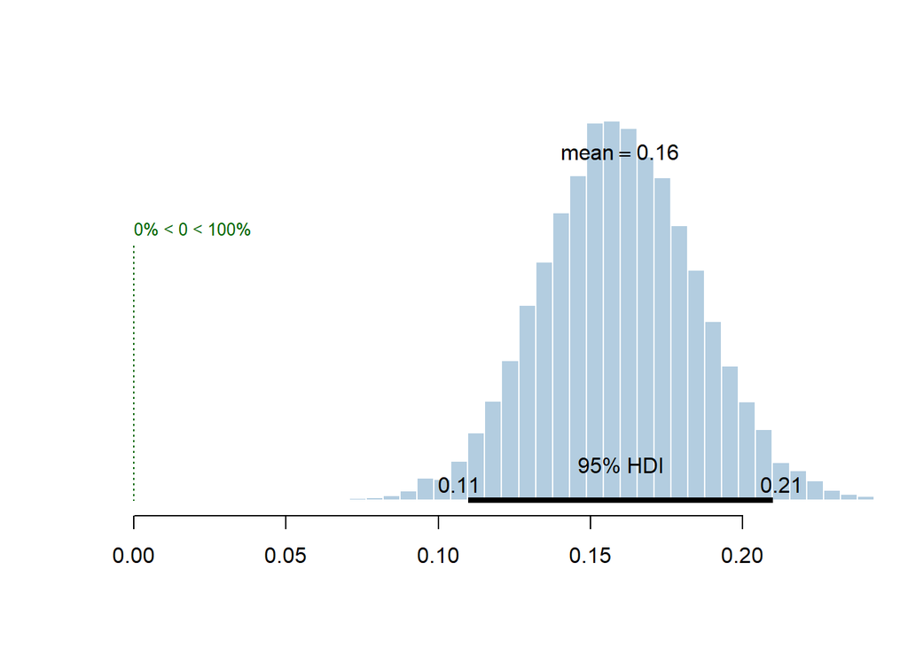

```r
Diff_Att_NotAtt_Acq_Low = Acquisition_Low_Attended - Acquisition_Low_NotAttended
plotPost(Diff_Att_NotAtt_Acq_Low, xlab = "", col = "#b3cde0", cex = 1, showCurve = FALSE, compVal = 0)
```

Check the difference between attended and not attended in extinction high rewarded

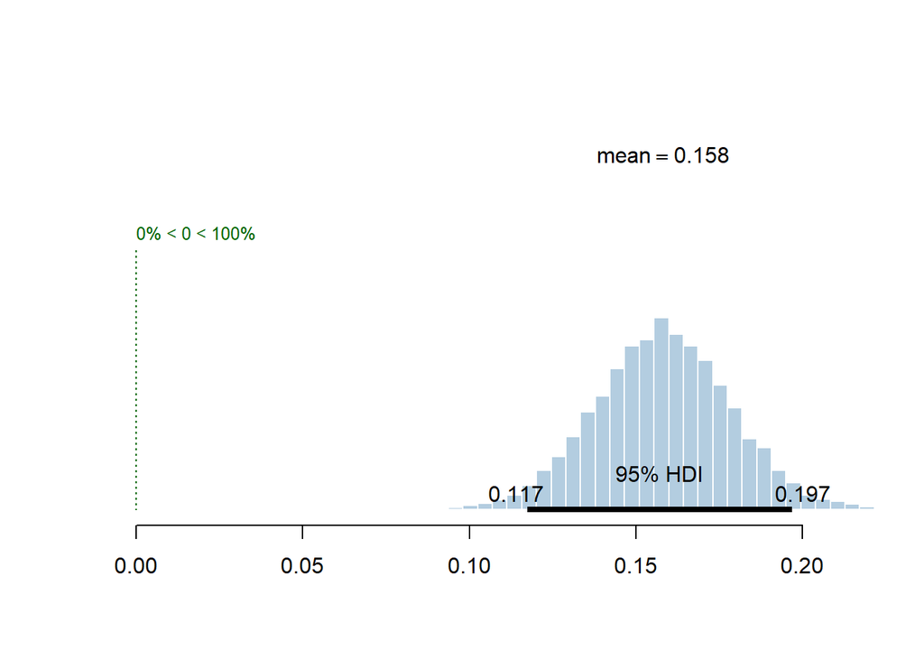

```r
Diff_Att_NotAtt_Ext_High = Extinction_High_Attended - Extinction_High_NotAttended
plotPost(Diff_Att_NotAtt_Ext_High, xlab = "", col = "#b3cde0", cex = 1, showCurve = FALSE, compVal = 0)
```

Check the difference between attended and not attended in extinction low rewarded

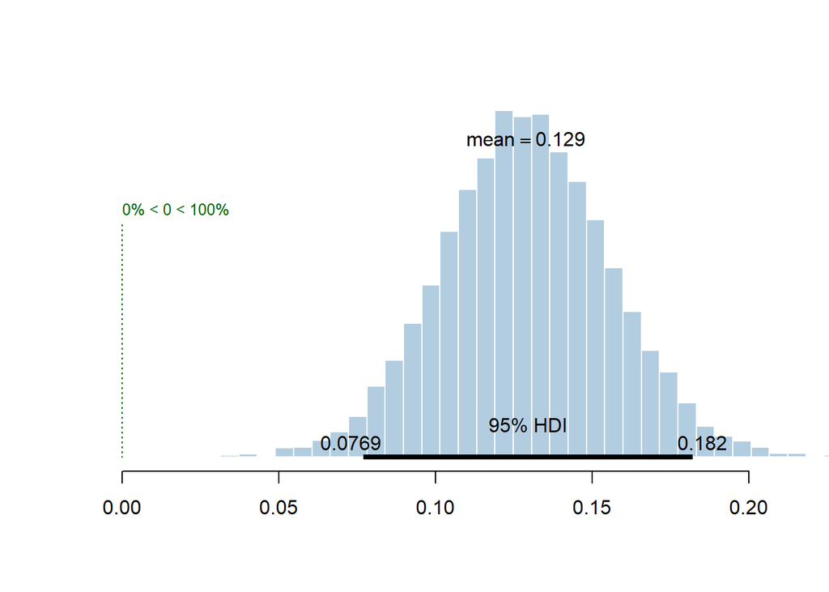

```r
Diff_Att_NotAtt_Ext_Low = Extinction_Low_Attended - Extinction_Low_NotAttended
plotPost(Diff_Att_NotAtt_Ext_Low, xlab = "", col = "#b3cde0", cex = 1, showCurve = FALSE, compVal = 0)
```

#### Comparison between phases

Check the difference between baseline and acquisition in high reward attended

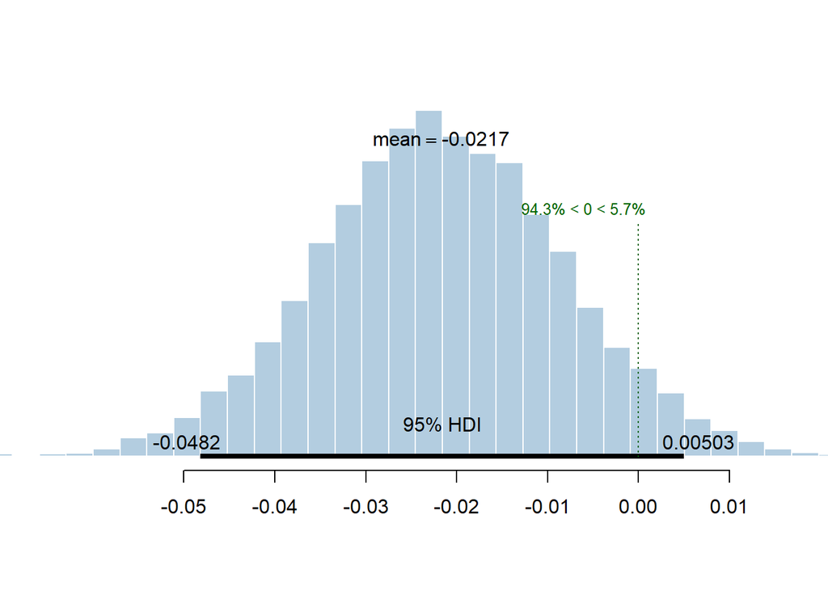

```r
Diff_Bsln_Acq_High_Att = Baseline_High_Attended - Acquisition_High_Attended
plotPost(Diff_Bsln_Acq_High_Att, xlab = "", col = "#b3cde0", cex = 1, showCurve = FALSE, compVal = 0)
```

Check the difference between baseline and acquisition in low reward attended

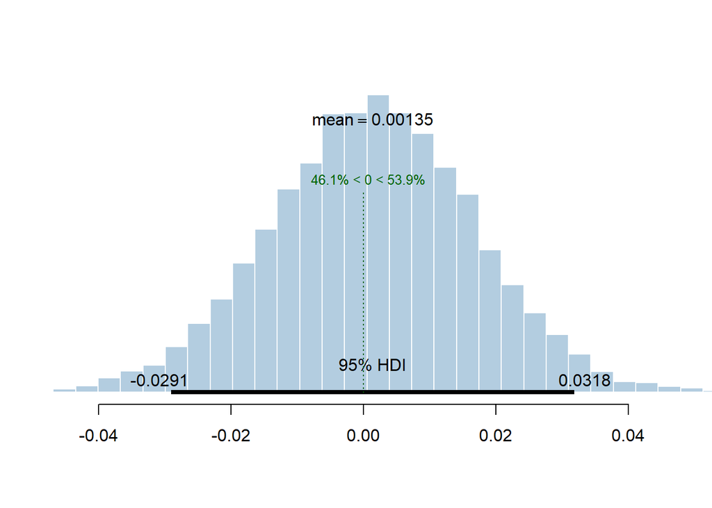

```r
Diff_Bsln_Acq_Low_Att = Baseline_Low_Attended - Acquisition_Low_Attended
plotPost(Diff_Bsln_Acq_Low_Att, xlab = "", col = "#b3cde0", cex = 1, showCurve = FALSE, compVal = 0)
```

Check the difference between baseline and acquisition in high reward not attended

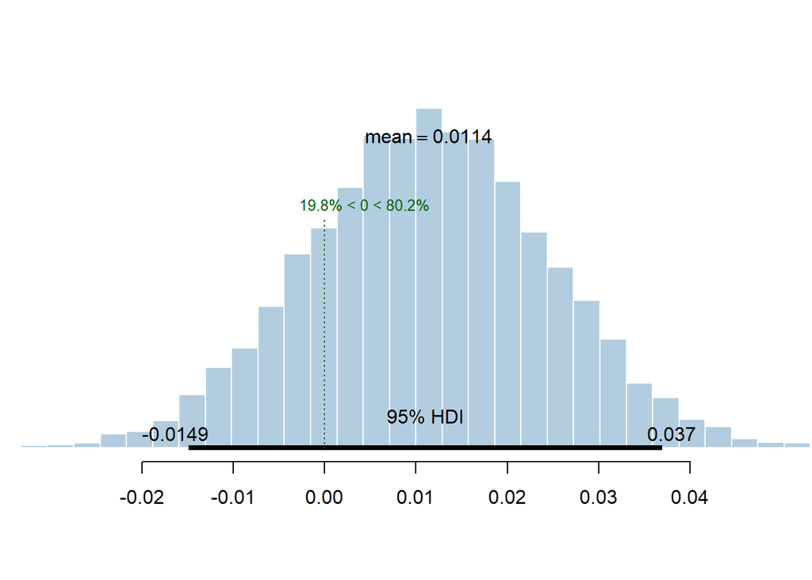

```r
Diff_Bsln_Acq_High_NotAtt = Baseline_High_NotAttended - Acquisition_High_NotAttended
plotPost(Diff_Bsln_Acq_High_NotAtt, xlab = "", col = "#b3cde0", cex = 1, showCurve = FALSE, compVal = 0)
```

Check the difference between baseline and acquisition in low reward not attended

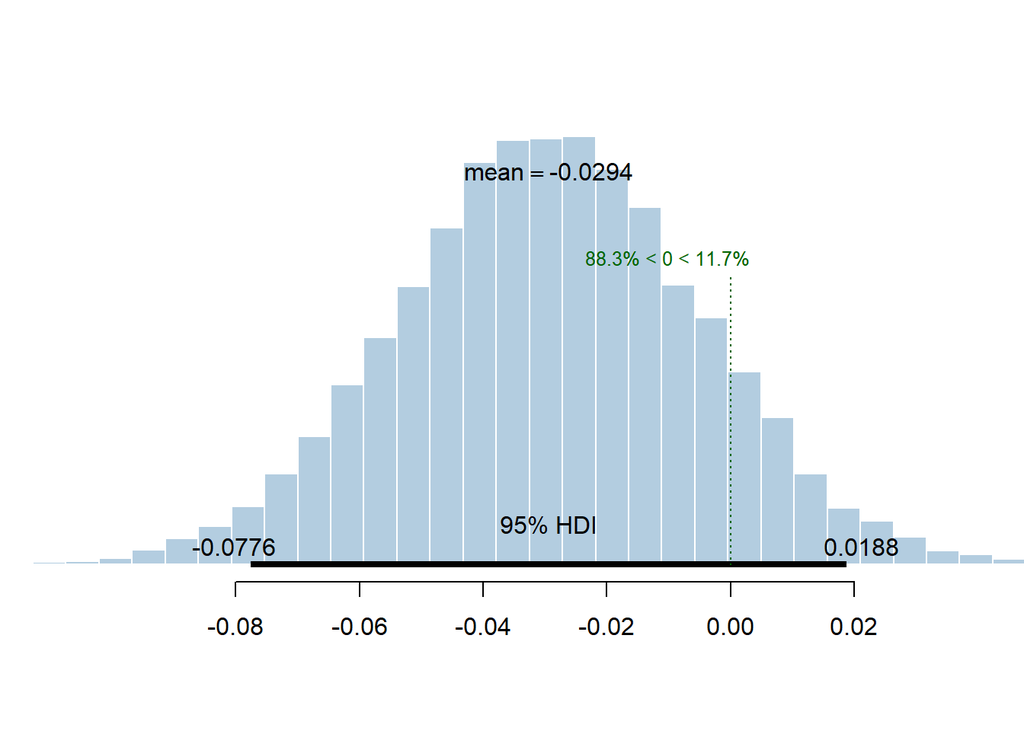

```r
Diff_Bsln_Acq_Low_NotAtt = Acquisition_Low_NotAttended - Baseline_Low_NotAttended
plotPost(Diff_Bsln_Acq_Low_NotAtt, xlab = "", col = "#b3cde0", cex = 1, showCurve = FALSE, compVal = 0)
```

Check the difference between acquisition and extinction in high reward attended

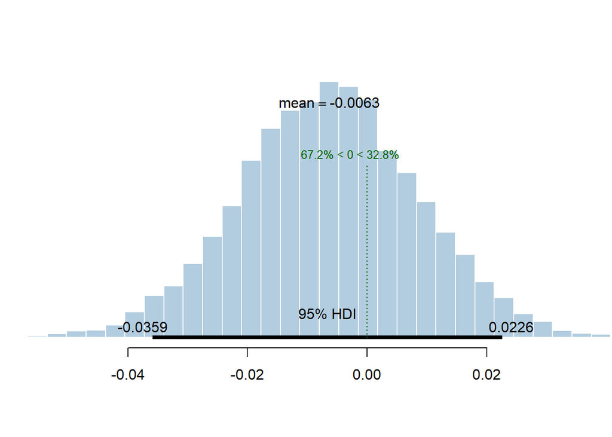

```r
Diff_Acq_Ext_High_Att = Acquisition_High_Attended - Extinction_High_Attended
plotPost(Diff_Acq_Ext_High_Att, xlab = "", col = "#b3cde0", cex = 1, showCurve = FALSE, compVal = 0)
```

Check the difference between acquisition and extinction in low reward attended

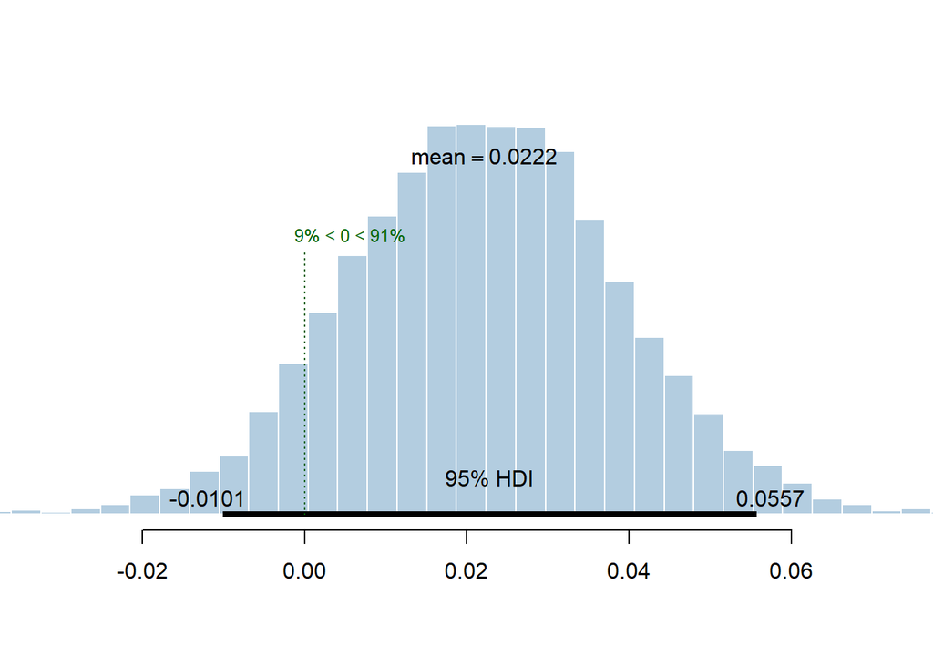

```r
Diff_Acq_Ext_Low_Att = Extinction_Low_Attended - Acquisition_Low_Attended
plotPost(Diff_Acq_Ext_Low_Att, xlab = "", col = "#b3cde0", cex = 1, showCurve = FALSE, compVal = 0)
```

Check the difference between acquisition and extinction in high reward not attended

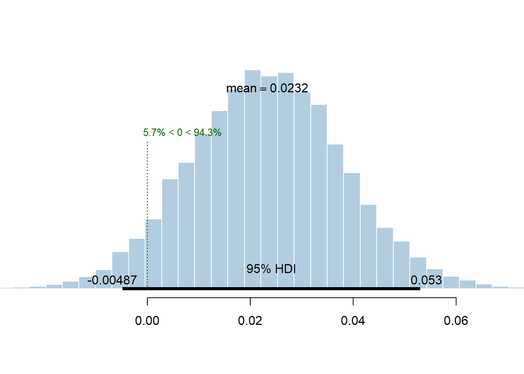

```r
Diff_Acq_Ext_High_NotAtt = Extinction_High_NotAttended - Acquisition_High_NotAttended
plotPost(Diff_Acq_Ext_High_NotAtt, xlab = "", col = "#b3cde0", cex = 1, showCurve = FALSE, compVal = 0)
```

Check the difference between acquisition and extinction in low reward not attended

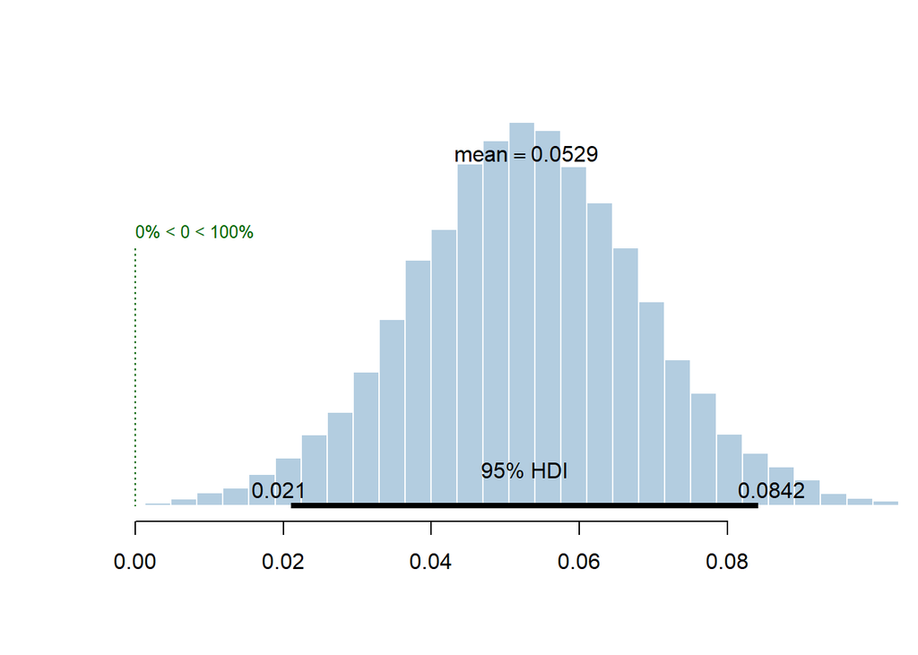

```r
Diff_Acq_Ext_Low_NotAtt = Extinction_Low_NotAttended - Acquisition_Low_NotAttended
plotPost(Diff_Acq_Ext_Low_NotAtt, xlab = "", col = "#b3cde0", cex = 1, showCurve = FALSE, compVal = 0)
```

#### Baseline difference

Check the difference between high and low reward in baseline attended

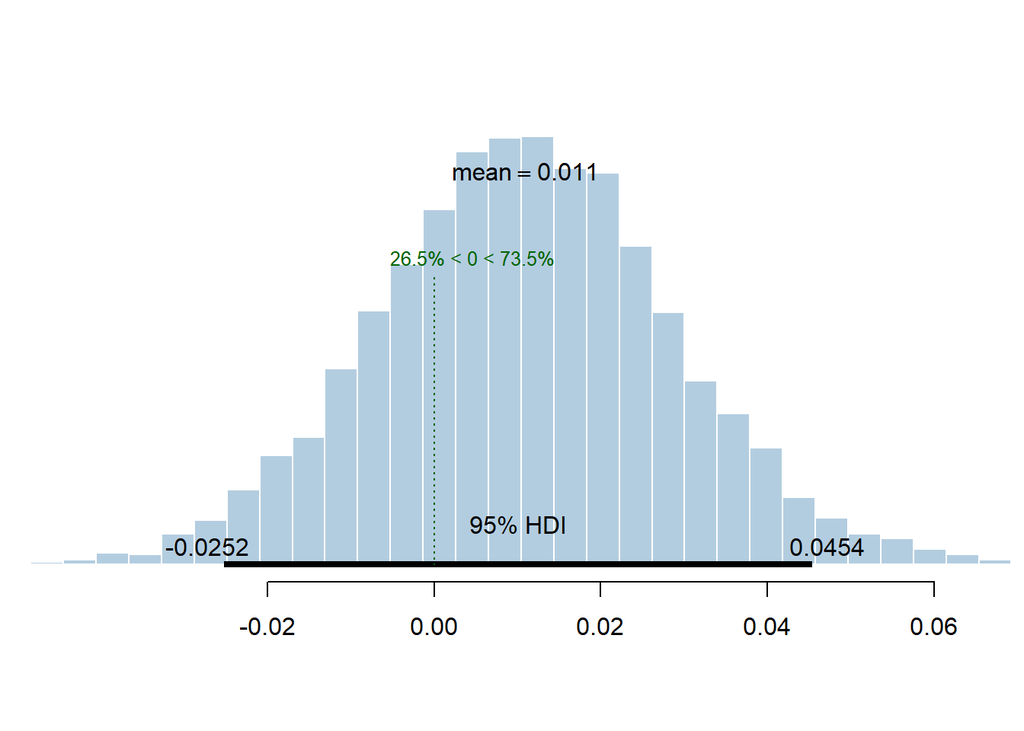

```r
Diff_Bsln_High_Low_Att = Baseline_High_Attended - Baseline_Low_Attended
plotPost(Diff_Bsln_High_Low_Att, xlab = "", col = "#b3cde0", cex = 1, showCurve = FALSE, compVal = 0)
```

Check the difference between high and low reward in baseline not attended

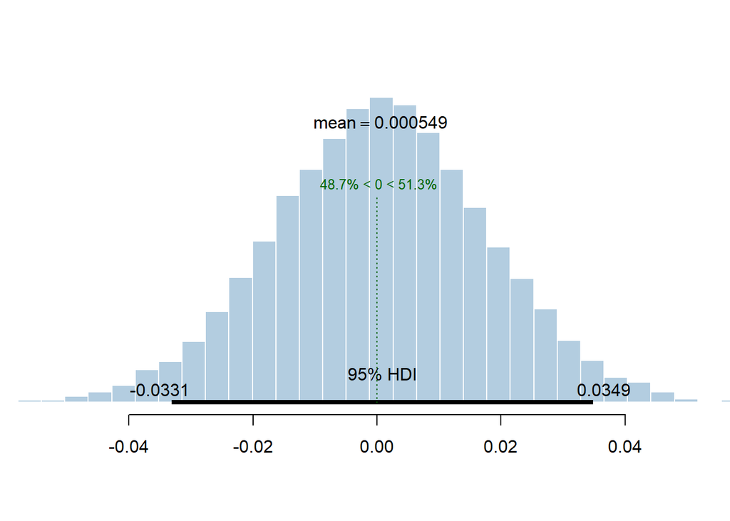

```r
Diff_Bsln_High_Low_NotAtt = Baseline_High_NotAttended - Baseline_Low_NotAttended
plotPost(Diff_Bsln_High_Low_NotAtt, xlab = "", col = "#b3cde0", cex = 1, showCurve = FALSE, compVal = 0)
```

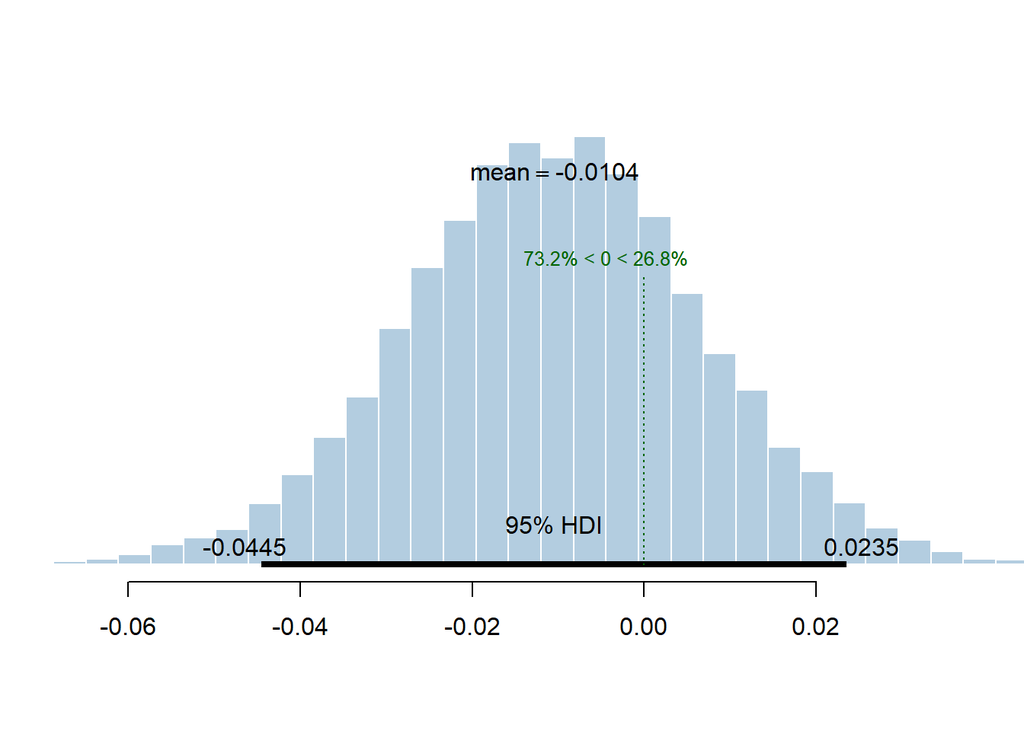

```r
Diff_Bsln_Acq_High_vs_Low_in_attended_vs_unattended = Diff_Bsln_High_Low_NotAtt - Diff_Bsln_High_Low_Att
plotPost(Diff_Bsln_Acq_High_vs_Low_in_attended_vs_unattended, xlab = "", col = "#b3cde0", showCurve = FALSE, cex = 1, compVal = 0)
```

```r
paste("Mean = ",round(mean(Diff_Bsln_Acq_High_vs_Low_in_attended_vs_unattended), digits = 2), " [", round(hdi(Diff_Bsln_Acq_High_vs_Low_in_attended_vs_unattended)[[1]], digits = 2), " ", round(hdi(Diff_Bsln_Acq_High_vs_Low_in_attended_vs_unattended)[[2]], digits = 2), "]")
```

```
## [1] "Mean =  -0.01  [ -0.04   0.02 ]"
```